# Investigating Mass Die-Off Events around the Southwest Coast of Newfoundland

Author

Tom Spencer-Hicken

## 2025 Mass Die-Off Event near Harbour Breton

An article, written by Jenna Head, indicated a mass die-off of salmon in 3 separate aquaculture open-net pens near Harbour Breton, Newfoundland, around the timeline of 31 August 2025, with 1.5M total fish affected. This article forms the basis of the idea for my project with regards to the possibility of internal Kelvin waves (iKWs) and subsequent upwelling and downwelling events being a potential cause of the die-off. The article can be found here: https://www.cbc.ca/news/canada/newfoundland-labrador/mowi-canada-nl-salmon-dead-1.7623833.

## Initial Validation of GLORYS Model Performance

To investigate the potential role of iKWs in the mass die-off event, we first need to validate the performance of the GLORYS model in capturing localised sea surface height (SSH) and water temperature (WT) variability around the Harbour Breton area. Unfortunately, with regards to the Headlands mooring data, there is only one site on the South coast of Newfoundland, in Arnold’s Cove, which isn’t a major upset because it is the neighboring embayment.

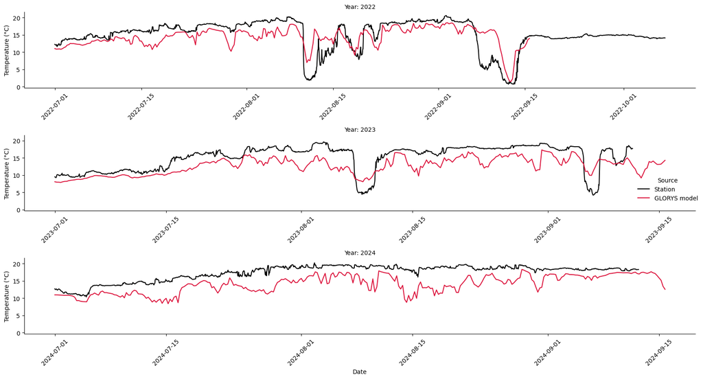

Arnolds Cove and GLORYS Time-Series Data.

The WT data does not perfectly align between the mooring and the GLORYS model, but there is a general agreement in the timing of temperature swings, which may be indicative of upwelling events. Therefore, we can move on to investigate the SSH and WT data in the nighboring embayment, Harbour Breton to investigate if we see any overlap in timeline between iKW and upwelling/downwelling signals with the mass die-off event.

## Transect and Hövmoller Analysis of Harbour Breton Area

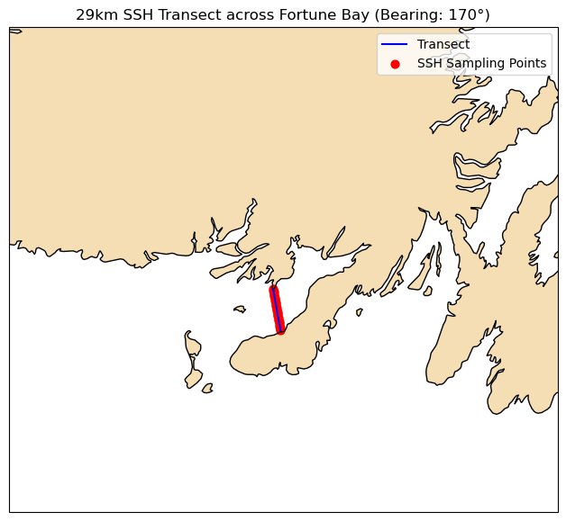

Fortune Bay Transect

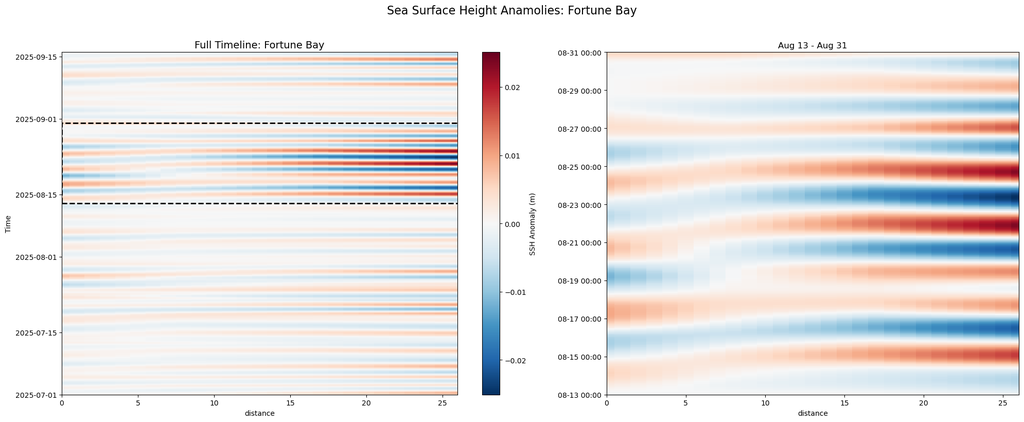

Fortune Bay Transect Hövmoller

[video not shown]

Fortune Bay Local SSH Anomaly

Just a quick note… I constructed multiple transects protruding from different areas of coast around the Harbour Breton area, where the data closer to the coast would get lost perhaps due to the resolution of the model or the variability of the shape of the coastline. However, the transect shown above is one that seems to capture data from either end of the transect nicely.

Just a quick inspection shows that there appears to be a prolonged iKW event in the Fortune Bay area around the timeline of the mass die-off event, which is indicated by the dotted box in the figure above. So far from my exploration using this cross-bay transect methodology with the same wave parameters, I have not yet seen such a prolonged event. In addition, it is also worth noting that the SSH anomaly scale is greater than other events I have observed thus far (0.02 m maximum compared to 0.01 m), which indicates a more intense iKW event than ones I have previously observed.

## Water Temperature Analysis of Harbour Breton Area

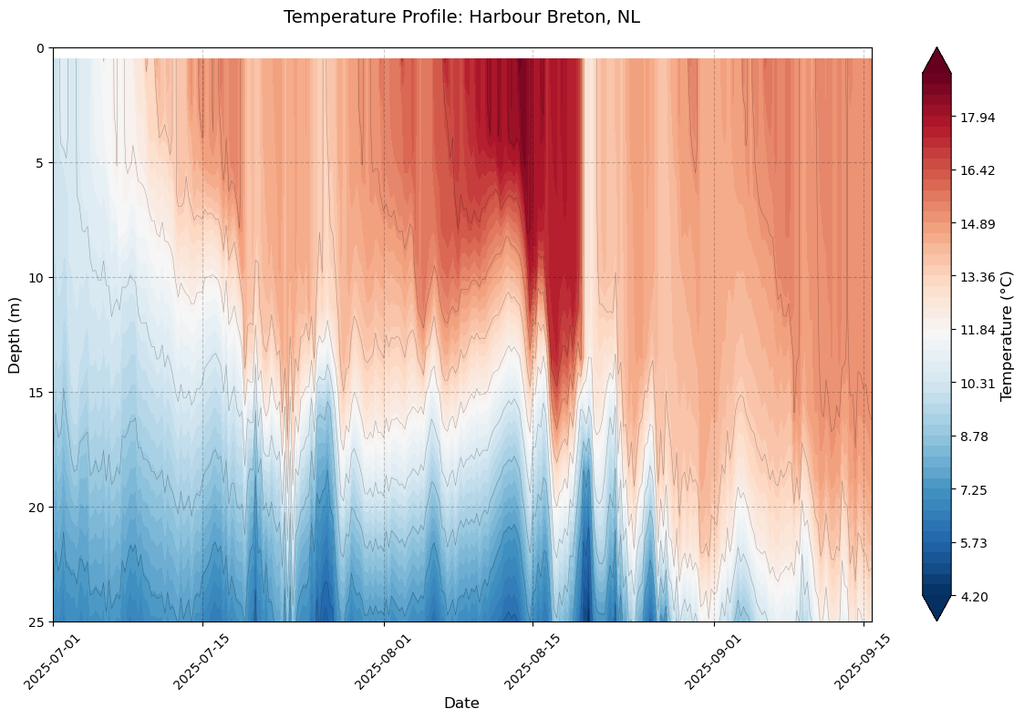

Harbour Breton Temperature Profile

Quick inspection shows that there is a significant warming event around mid August 2025, near the sea surface extending to ~15m depth. This event is then followed by less warm, but still warm, water temperatures occuring from the surface pertruding to 25m depth. This lack of stratification could lead to a thermal squeeze effect where fish have no way to ‘hide’ from the warm water, which could be a potential cause of the mass die-off event.

## Next Step into this Investigation

I would like to do the same analysis for the mass die-off event that occured in 2019 https://www.cbc.ca/news/canada/newfoundland-labrador/government-aquaculture-act-changes-1.5316940 in the same area (where most open net salmon pens are located), to see if there are any similar patterns in the SSH and WT data. If there are, then this would further support the hypothesis that iKWs and subsequent upwelling/downwelling events could be a potential cause of mass die-off events in this area. However, I need model data from 2019 as GLORYS does not have the temporal range for me to analyse 2019 data. A possibility we are considering is CIOPS-E data.